← 使い方一覧に戻る

# ファンクラブ運営

## 概要

ファンクラブ(FC)を運営し、会員管理や特典付与を行う場合の使い方です。

ステータス機能を活用して会員を分類・管理します。

## 手順

### 1. 初回セットアップ

1. **アプリ起動**:
   - BondLog をブラウザで開き、ダッシュボードを表示します

[figure not shown]

   ダッシュボード

### 2. ステータス定義

1. **ステータス管理画面へ移動**:
   - 「🏷️ ステータス管理」タブを選択します

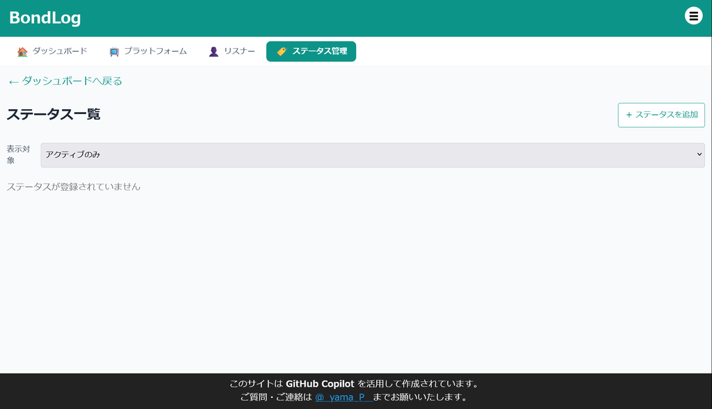

   ステータス管理

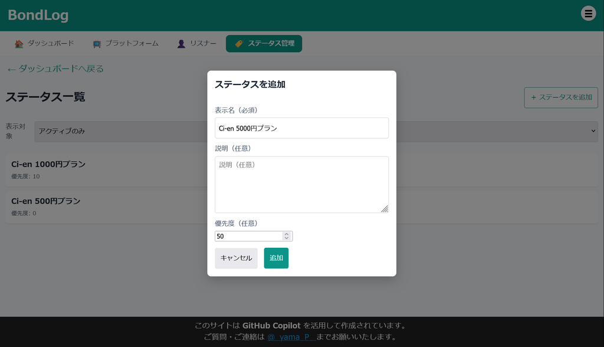

   ステータス追加

### 3. 会員管理

1. **リスナー登録**:
   - 「👤 リスナー」タブから「＋ リスナーを追加」ボタンを押し会員を登録します

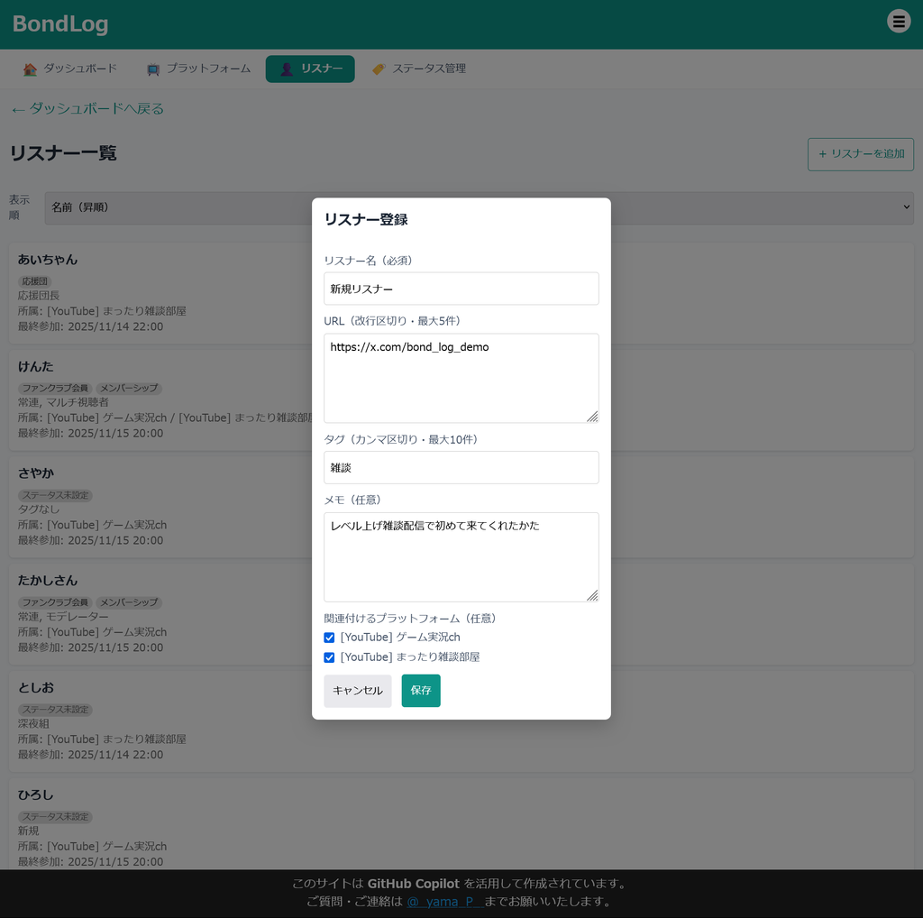

   リスナー追加

   - **リスナー名** にはFC会員の名前を入力します
   - **URL** にはFC会員が利用している SNS などのURLを入力します(任意)
   - **タグ** で会員に任意のタグを付与することができます(任意)
   - **メモ** は自由にメモを入力できます(任意)
   - **関連付けるプラットフォーム** はファンクラブ運営でのみ利用する場合は表示されません。配信活動とあわせて利用する場合には、該当リスナーが来てくれる配信プラットフォームにチェックをつけます
     - 詳しくは 単一プラットフォームでの配信開始 など配信に関する使い方ガイドをご確認ください
2. **入会処理(ステータス付与)**:
   - 「👤 リスナー」タブから該当の会員を選択し、リスナー詳細画面を表示します

[figure not shown]

   リスナー詳細

   - 「ステータスを管理」ボタンを押します

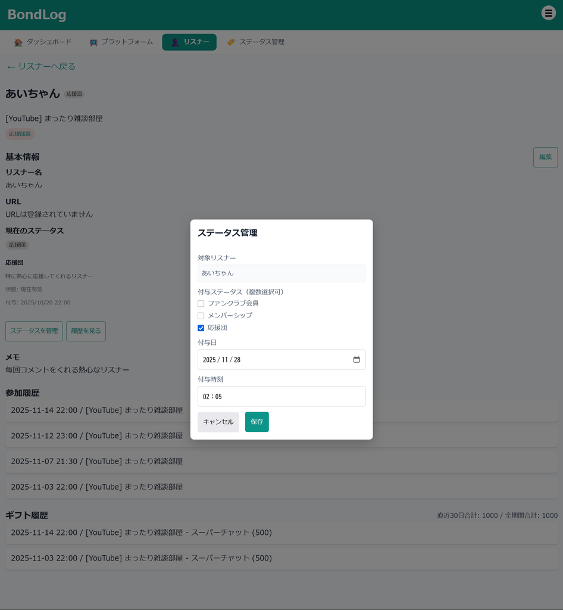

   ステータス付与

   - **付与ステータス（複数選択可）** には `2. ステータス定義` で登録したステータスが表示されているので、このなかから該当FC会員に付与するステータスを選択します
   - **日付** にはステータスの付与日時を指定できます
     - 初期状態で現在日時が設定されています
     - ステータスにチェックを付けて「保存」するときには付与日時として扱われます
     - チェックがついているステータスを外して「保存」するときには解除日時として扱われます
     - ファンクラブに入会してくれた日（もしくはその月の1日）を付与日時、ファンクラブを退会した日（もしくはその月の月末）を解除日時として利用可能です
   - 入力後「保存」ボタンを押してステータスを付与します
3. **会員の確認**:
   - リスナー一覧でステータスバッジを確認できます

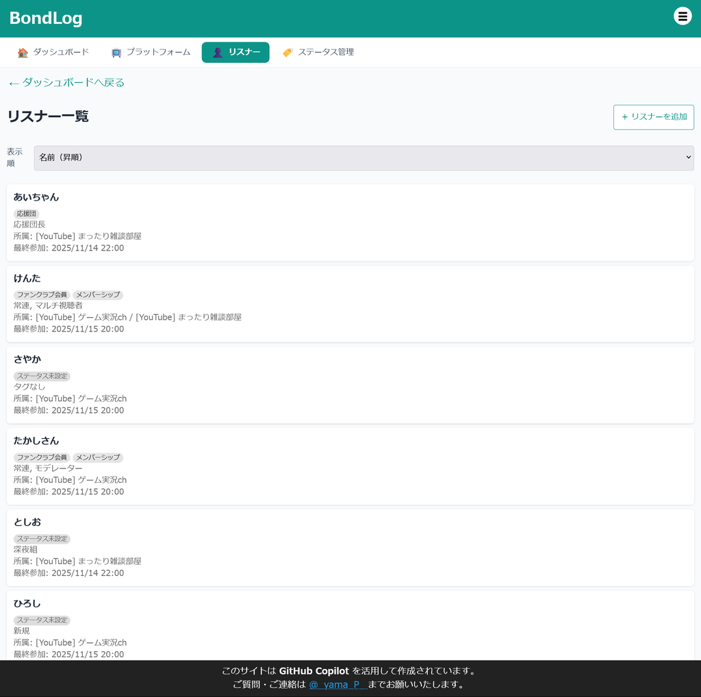

   リスナー一覧

4. **退会処理(ステータス解除)**:
   - 退会するFC会員のリスナー詳細画面を表示します
   - 「ステータスを管理」ボタンを押します
   - **付与ステータス（複数選択可）** で退会したファンクラブのチェックボックスを外します
   - **日付** にはステータスの解除日時を指定できます
     - 初期状態で現在日時が設定されています
     - チェックを外して「保存」するときには解除日時として扱われます
     - ファンクラブを退会した日（もしくはその月の月末）を解除日時として設定できます
   - 入力後「保存」ボタンを押してステータスを解除します

**注意: 「ステータスを管理」画面では新規付与と解除のみ可能です。日付の修正や誤って付与したステータスの削除は必ず履歴画面から行ってください**

**ステータス付与を誤った場合の修正方法**: - リスナー詳細画面の「履歴を見る」ボタンを押してステータス履歴画面を開きます

[figure not shown]

ステータス履歴

- 修正したい履歴の「編集」ボタンを押します
- 「付与日時」や「解除日時」を修正して「保存」ボタンを押します
- 誤って付与してしまったステータスは「削除」ボタンで削除することもできます
  - **「削除」はステータス付与をなかったことにする機能です、退会(ステータス解除)とは異なるのでご注意ください**

### 4. データ保存

1. **バックアップ**:
   - 定期的にメニューから「💾 エクスポート」を実行してバックアップします
   - **BondLog.html（オフライン版）をお使いの場合**: ダッシュボード上部の「BondLog 自動バックアップ」カードからフォルダを選択すると、30秒ごとに差分を検知してJSONファイルを自動保存できます（Chrome / Edge 等の Chromium 系ブラウザで利用可能）。詳しくは ユーザーガイド を参照してください。

## ポイント

- ステータス履歴で入会・退会の記録を保持できます。
- Discordロールや特典付与の管理簿として活用できます。
- 優先度を設定することで、複数のステータスを持つ会員の表示順序を制御できます。

← 使い方一覧に戻る